# Exercises for week 5

## The Human dataset

I will start off by exploring the structure and dimensions of my ‘human’ dataset.

```r
human <- read.table("/Users/Noora/Documents/IODS-project/data/create_human_.txt", header = TRUE)
dim(human)
```

```
## [1] 155   8
```

```r
str(human)
```

```
## 'data.frame':    155 obs. of  8 variables:
##  $ High_educ_f_m: num  1.007 0.997 0.983 0.989 0.969 ...
##  $ F_m_working  : num  0.891 0.819 0.825 0.884 0.829 ...
##  $ Educ_exp     : num  17.5 20.2 15.8 18.7 17.9 16.5 18.6 16.5 15.9 19.2 ...
##  $ Life_exp     : num  81.6 82.4 83 80.2 81.6 80.9 80.9 79.1 82 81.8 ...
##  $ GNI_         : int  64992 42261 56431 44025 45435 43919 39568 52947 42155 32689 ...
##  $ Mat_deaths   : int  4 6 6 5 6 7 9 28 11 8 ...
##  $ Young_births : num  7.8 12.1 1.9 5.1 6.2 3.8 8.2 31 14.5 25.3 ...
##  $ Parl_seats   : num  39.6 30.5 28.5 38 36.9 36.9 19.9 19.4 28.2 31.4 ...
```

From the outputs I see that the dataset has 155 observation and 8 variables. However, I know that the row names denote the variable ‘Country’, thus the dataset has in reality 9 variables, not 8. For example the last row of my dataset is:

```r
library(knitr)
knitr::kable(tail(human, n = 1))
```

|  | High_educ_f_m | F_m_working | Educ_exp | Life_exp | GNI_ | Mat_deaths | Young_births | Parl_seats |
| --- | --- | --- | --- | --- | --- | --- | --- | --- |
| Niger | 0.3076923 | 0.4459309 | 5.4 | 61.4 | 908 | 630 | 204.8 | 13.3 |

Here I have 8 named columns, but the first column shows the name of the country in question (in this case Niger), so in effect there are 9 variables.

The original ‘human’ dataset includes variables that relate to the Human Development Index (HDI), and to other indexes such as Gender Development Index (GDI), and combines indicators from most countries. The dataset originally consisted of more than the 9 variables shown in my dataset, but it has been wrangled and reduced to 9 variables, and to only obsrvations that relate to countries, and it includes only those observations without missing values. The variable ‘Country’ is the name of the country in question. The other 8 variables in my dataset relate to two topics: Health and knowledge, and Empowerment. The variables related to Empowerment in my dataset are:

- **High_educ_f_m**: Proportion of females with at least secondary education / Proportion of males with at least secondary education
- **F_m_working**: Proportion of females in the labour force / Proportion of males in the labour force
- **Parl_seats**: Percetange of female representatives in parliament

The variables related to Health and knowledge in my dataset are:

- **Educ_exp**: Expected years of schooling
- **Life_exp**: Life expectancy at birth
- **GNI_**: Gross National Income per capita
- **Mat_deaths**: Maternal mortality ratio
- **Young_births**: Adolescent birth rate

The source for the definitions of the variables is [this website](https://raw.githubusercontent.com/TuomoNieminen/Helsinki-Open-Data-Science/master/datasets/human_meta.txt).

## Overview of the data

Here is a graphical overview of the data:

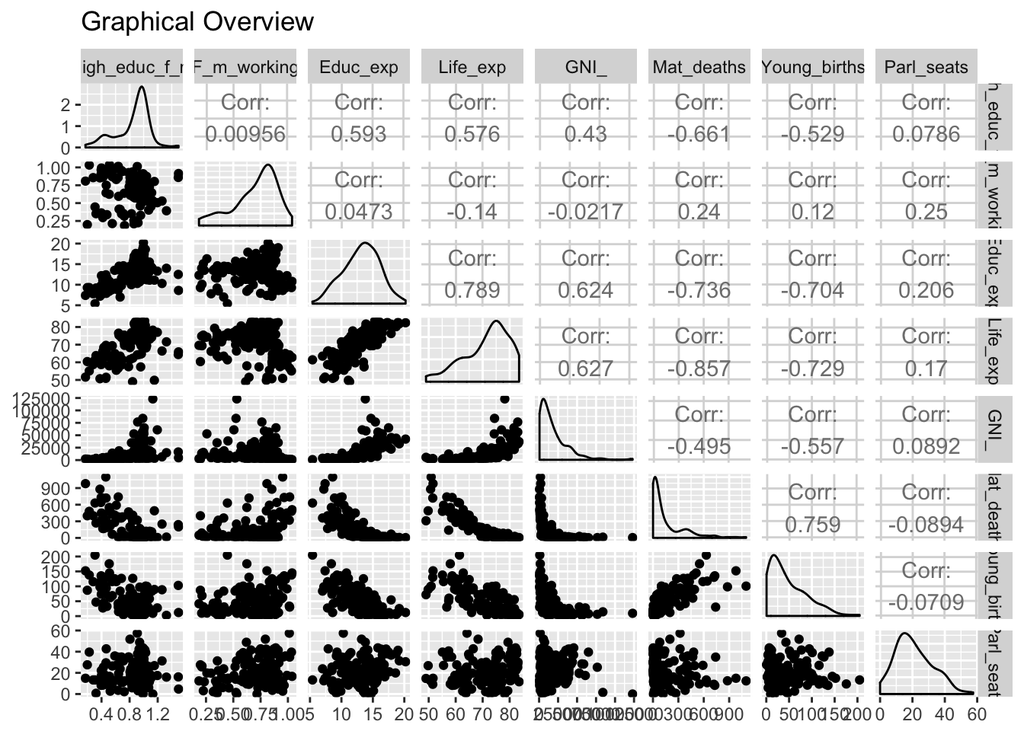

```r
library(ggplot2)
library(GGally)
GraphOV <- ggpairs(human, mapping = aes(), title = "Graphical Overview", lower = list(combo = wrap("facethist", bins = 20)))
GraphOV
```

Here are also summaries of the variables in my dataset (the knitr part of the code just formats the result into a nice table):

```r
knitr::kable(summary(human))
```

|  | High_educ_f_m | F_m_working | Educ_exp | Life_exp | GNI_ | Mat_deaths | Young_births | Parl_seats |
| --- | --- | --- | --- | --- | --- | --- | --- | --- |
|  | Min. :0.1717 | Min. :0.1857 | Min. : 5.40 | Min. :49.00 | Min. : 581 | Min. : 1.0 | Min. : 0.60 | Min. : 0.00 |
|  | 1st Qu.:0.7264 | 1st Qu.:0.5984 | 1st Qu.:11.25 | 1st Qu.:66.30 | 1st Qu.: 4198 | 1st Qu.: 11.5 | 1st Qu.: 12.65 | 1st Qu.:12.40 |
|  | Median :0.9375 | Median :0.7535 | Median :13.50 | Median :74.20 | Median : 12040 | Median : 49.0 | Median : 33.60 | Median :19.30 |
|  | Mean :0.8529 | Mean :0.7074 | Mean :13.18 | Mean :71.65 | Mean : 17628 | Mean : 149.1 | Mean : 47.16 | Mean :20.91 |
|  | 3rd Qu.:0.9968 | 3rd Qu.:0.8535 | 3rd Qu.:15.20 | 3rd Qu.:77.25 | 3rd Qu.: 24512 | 3rd Qu.: 190.0 | 3rd Qu.: 71.95 | 3rd Qu.:27.95 |
|  | Max. :1.4967 | Max. :1.0380 | Max. :20.20 | Max. :83.50 | Max. :123124 | Max. :1100.0 | Max. :204.80 | Max. :57.50 |

From the summary table I see immediately that many of the variables have fairly large ranges. For example some countries have no women at all in parliament (as the min value of Parl_seats is 0), whereas some have more women in parliament than men (as the max value is above 50%). This already suggests to me that some countries in the dataset are quite different from each other. Similarly there seems to be large differences between some countries with regard to all the other variables. For example in some countries the expected years of schooling are under 6 and in others above 20. At the same time, expected years of schooling seems to be among those variables where many countries also are fairly similar, with 50% of countries expecting inhabitants to have between 11 and 15 years of schooling. This variable is also the one that seems to be the closest to being normally distributd from all the variables when looking at the graphical overview.

The graphical overview indicates that some of the variables may be related to one another. For example it seems that as adolescent birth rate increase, so does maternal mortality ratio. Not surprisingly, there also seems to be a relationship between maternal mortality ratio and life expectancy, with higher maternal mortality ratios corresponding to lower lif expectancies. In fact, a great number of the variables seem to be correlated. Another example of such variables are education and life expectancies: the higher the education expectancy, the higher also the life expectancy and vice versa. Among those variable pairs that don’t seem to be strongly correlated are e.g. expected years of schooling and percetange of female representatives in parliament.

## Principal component analysis (PCA)

Next I will perform principal component analysis (PCA) without standardising the dataset. First I will look at the variability captured by the principal components. I will also draw a biplot displaying the observations with PC1 in coordinate x-axis and PC2 in y-axis.

```r
pca_human <- prcomp(human)
summary(pca_human)
```

```
## Importance of components:
##                              PC1      PC2   PC3   PC4   PC5   PC6    PC7
## Standard deviation     1.854e+04 185.5219 25.19 11.45 3.766 1.566 0.1912
## Proportion of Variance 9.999e-01   0.0001  0.00  0.00 0.000 0.000 0.0000
## Cumulative Proportion  9.999e-01   1.0000  1.00  1.00 1.000 1.000 1.0000
##                           PC8
## Standard deviation     0.1591
## Proportion of Variance 0.0000
## Cumulative Proportion  1.0000
```

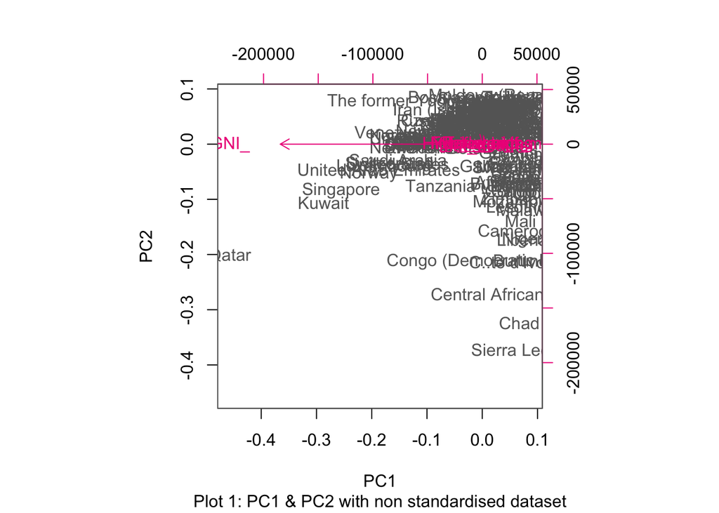

```r
biplot(pca_human, choices = 1:2, cex = c(1, 1), col = c("grey40", "deeppink2"), sub = "Plot 1: PC1 & PC2 with non standardised dataset")
```

However, I should first standardise the variables to be able to conduct analysis, so I repeat the PCA, and look at the variability and biplot of the tandardised dataset next.

```r
human_std <- scale(human)
pca_human_std <- prcomp(human_std)
summary(pca_human_std)
```

```
## Importance of components:
##                           PC1    PC2     PC3     PC4     PC5     PC6
## Standard deviation     2.0708 1.1397 0.87505 0.77886 0.66196 0.53631
## Proportion of Variance 0.5361 0.1624 0.09571 0.07583 0.05477 0.03595
## Cumulative Proportion  0.5361 0.6984 0.79413 0.86996 0.92473 0.96069
##                            PC7     PC8
## Standard deviation     0.45900 0.32224
## Proportion of Variance 0.02634 0.01298
## Cumulative Proportion  0.98702 1.00000
```

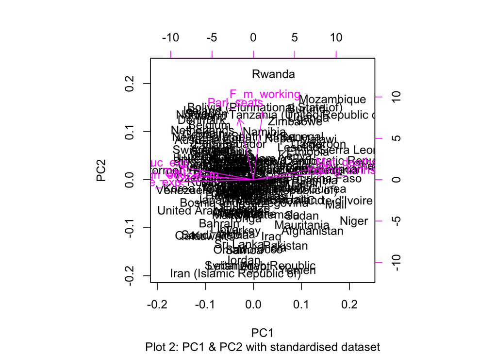

```r
biplot(pca_human_std, choices = 1:2, cex = c(1, 1), col = c(1, 14), sub = "Plot 2: PC1 & PC2 with standardised dataset")
```

The results with and without standardising are very different. When the dataset is not standardised, PC1 explains nearly all of the variance (99.99%) in the original variables, thus PC2 contribute very little and the other PCs not at all toward explaining the variance. From plot 1 I can also see that there is only one very visible arrow (‘GNI_’), which is parallel to x-axis, meaning that GNI has high correlation with PC1. The reason why GNI is so dominant is because in the non standardised dataset GNI has much higher values than any of the other variables, which is why standardisation of the dataset is needed.GNI also has clearly the largest standard deviation in this model.

With standardising, PC1 still explains most of the variance in the original variables, with its proportion of variance being 54%. All 8 PCs are needed to get explain all of the variance in the original variables. In plot 2 I see all the variables mapped out clearly, with none of the variables having noticably greater standard deviation than the others.The arrows point to different directions, with some variables being correlated with PC1 whilst others with PC2 (see section below). In the second plot countries are also more evenly distributed in the scatter plot, whereas in picture 1 they were mainly scattered to the top right cornr of the plot.

## Interpreting PC1 and PC2

My personal interpretation of the first two principal component dimensions (PC1 and PC2) based on the biplot of the standardised dataset is that PC1 relates (mainly) to the topic ‘Health and knowledge’ and PC2 relates to the topic ‘Empowerment’. The two ‘Empowerment’ related variables ‘F_m_working’ and ‘Parl_seats’ are fairly well parallel with the y-axis (have high correlation with PC2), whereas all the other variables are somewhat parallel with the x-axis (have high correlation with PC1). However, some of the variables seem to be positively related to PC1 and some negatively. ‘Mat_deaths’ and ‘Young_births’ arrows point to the right, whereas the education-related variables (‘Educ_exp’, ‘High_educ_f_m’), ‘GNI_’ and ‘Life_exp’ point to the opposite direction. It is not surprising that for example life expectancy and maternal mortality ratio arrows point to the opposite directions (high negative correlation), as high maternal mortality clearly must negatively relate to life expectancy. The ‘Health and knowledge’ and ‘Empowerment’ related variables (with the exception of ‘High_educ_f_m’) are (almost) orthogonal, meaning that they are uncorrelated with each other.

## The tea dataset

Next I move to another dataset - the tea dataset from the FactoMineR package.

```r
library(FactoMineR)
data("tea")
str(tea)
```

```
## 'data.frame':    300 obs. of  36 variables:
##  $ breakfast       : Factor w/ 2 levels "breakfast","Not.breakfast": 1 1 2 2 1 2 1 2 1 1 ...
##  $ tea.time        : Factor w/ 2 levels "Not.tea time",..: 1 1 2 1 1 1 2 2 2 1 ...
##  $ evening         : Factor w/ 2 levels "evening","Not.evening": 2 2 1 2 1 2 2 1 2 1 ...
##  $ lunch           : Factor w/ 2 levels "lunch","Not.lunch": 2 2 2 2 2 2 2 2 2 2 ...
##  $ dinner          : Factor w/ 2 levels "dinner","Not.dinner": 2 2 1 1 2 1 2 2 2 2 ...
##  $ always          : Factor w/ 2 levels "always","Not.always": 2 2 2 2 1 2 2 2 2 2 ...
##  $ home            : Factor w/ 2 levels "home","Not.home": 1 1 1 1 1 1 1 1 1 1 ...
##  $ work            : Factor w/ 2 levels "Not.work","work": 1 1 2 1 1 1 1 1 1 1 ...
##  $ tearoom         : Factor w/ 2 levels "Not.tearoom",..: 1 1 1 1 1 1 1 1 1 2 ...
##  $ friends         : Factor w/ 2 levels "friends","Not.friends": 2 2 1 2 2 2 1 2 2 2 ...
##  $ resto           : Factor w/ 2 levels "Not.resto","resto": 1 1 2 1 1 1 1 1 1 1 ...
##  $ pub             : Factor w/ 2 levels "Not.pub","pub": 1 1 1 1 1 1 1 1 1 1 ...
##  $ Tea             : Factor w/ 3 levels "black","Earl Grey",..: 1 1 2 2 2 2 2 1 2 1 ...
##  $ How             : Factor w/ 4 levels "alone","lemon",..: 1 3 1 1 1 1 1 3 3 1 ...
```

[output cut: 22 more lines]

```r
dim(tea)
```

```
## [1] 300  36
```

The dataset seems to have 36 variables and 300 observations. The variables are e.g. age, sex, lunch and dinner, and seem to relate to tea consumption. I want to only keep some interesting variables in my analysis, so I choose to focus on variables:

- frequency: ‘1/day’, ‘1 to 2/week’, ‘+2/day’ and ‘3 to 6/week’
- Tea: ‘Earl Grey’, ‘green’ and ‘black’
- sugar: ‘sugar’ and ‘no sugar’
- tea.time: ‘not tea time’ and ‘tea time’
- sex: ‘female’ (F) and ‘male’ (M)

I will next visualise these variables from the dataset.

```r
library(tidyr)
library(dplyr)
```

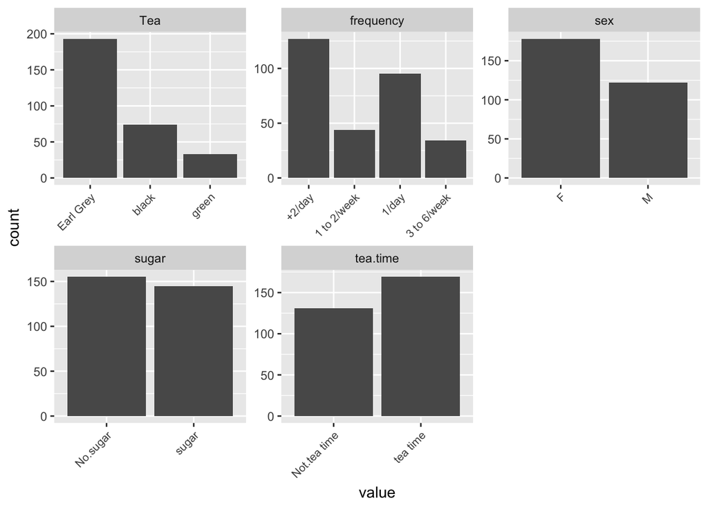

```r
keep_columns <- c("frequency", "Tea", "sugar", "tea.time", "sex")
te1 <- dplyr::select(tea, one_of(keep_columns))
gather(te1) %>% ggplot(aes(value)) + geom_bar() + theme(axis.text.x = element_text(angle = 45, hjust = 1, size = 8)) + facet_wrap("key", scales = "free")
```

## Multiple correspondence analysis and the tea data

Next I will perform MCA on the variables of the tea dataset that I kept for analysis.

```r
mca_tea <- MCA(te1, graph = FALSE)
summary(mca_tea)
```

```
##
## Call:
## MCA(X = te1, graph = FALSE)
##
##
## Eigenvalues
##                        Dim.1   Dim.2   Dim.3   Dim.4   Dim.5   Dim.6
## Variance               0.316   0.237   0.217   0.201   0.189   0.177
## % of var.             19.737  14.823  13.555  12.562  11.836  11.040
## Cumulative % of var.  19.737  34.559  48.114  60.676  72.512  83.552
##                        Dim.7   Dim.8
## Variance               0.146   0.117
## % of var.              9.112   7.336
## Cumulative % of var.  92.664 100.000
##
## Individuals (the 10 first)
##                 Dim.1    ctr   cos2    Dim.2    ctr   cos2    Dim.3    ctr
## 1            |  0.739  0.576  0.302 |  0.514  0.372  0.146 |  0.162  0.040
## 2            | -0.171  0.031  0.018 |  0.628  0.555  0.243 | -0.186  0.053
## 3            | -0.785  0.650  0.714 | -0.250  0.088  0.073 | -0.129  0.026
## 4            |  0.929  0.911  0.661 | -0.179  0.045  0.024 | -0.287  0.127
## 5            |  0.152  0.024  0.021 |  0.277  0.108  0.068 | -0.039  0.002
## 6            |  0.507  0.272  0.201 |  0.227  0.073  0.040 | -0.443  0.302
## 7            | -0.028  0.001  0.000 |  0.041  0.002  0.001 |  0.358  0.197
## 8            | -0.486  0.249  0.105 |  0.315  0.139  0.044 |  0.799  0.982
## 9            | -0.298  0.094  0.087 |  0.042  0.002  0.002 |  0.062  0.006
## 10           | -0.038  0.002  0.001 |  0.970  1.323  0.581 |  0.410  0.258
##                cos2
## 1             0.014 |
## 2             0.021 |
## 3             0.019 |
## 4             0.063 |
## 5             0.001 |
## 6             0.153 |
## 7             0.055 |
## 8             0.283 |
## 9             0.004 |
## 10            0.104 |
##
## Categories (the 10 first)
```

[output cut: 15 more lines]

```
## 3 to 6/week    0.505 |   0.745   5.803   0.071   4.607 |
## black         10.441 |   0.942  20.177   0.290   9.319 |
## Earl Grey    -14.687 |  -0.103   0.632   0.019  -2.397 |
## green          8.099 |  -1.508  23.079   0.281  -9.169 |
## No.sugar       8.542 |  -0.176   1.468   0.033  -3.138 |
## sugar         -8.542 |   0.188   1.569   0.033   3.138 |
## Not.tea time   4.913 |  -0.132   0.706   0.014  -2.015 |
##
## Categorical variables (eta2)
##                Dim.1 Dim.2 Dim.3
## frequency    | 0.294 0.012 0.514 |
## Tea          | 0.089 0.727 0.476 |
## sugar        | 0.351 0.244 0.033 |
## tea.time     | 0.393 0.081 0.014 |
## sex          | 0.452 0.122 0.048 |
```

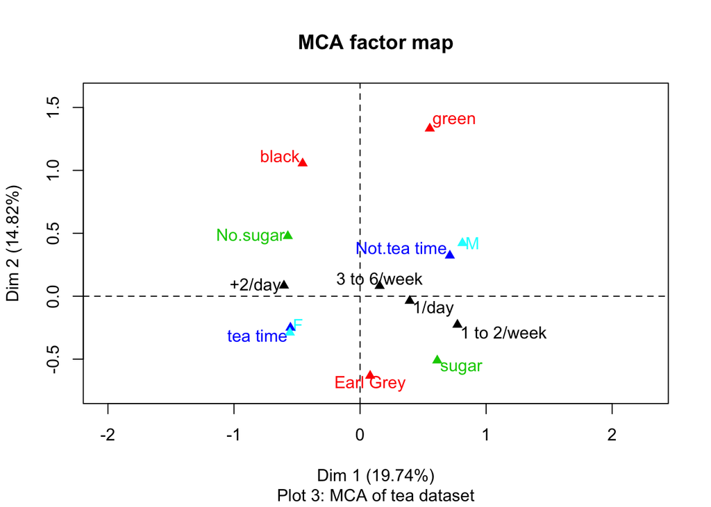

```r
plot(mca_tea, invisible = c("ind"), habillage = "quali", sub = "Plot 3: MCA of tea dataset")
```